# Emulating LMDZ SCM output

In this example we use primarily R and Stan files from **BuildEmulator** directory to construct and validate a GP emulator.

First we start with loading the necessary packages, functions and compilation of Stan files that are necessary to construct a GP emulator.

```r
setwd('..')
source('BuildEmulator/BuildEmulator.R')
```

We proceed to loading the data file `lmdzAWave1.RData`. The emulator inputs are saved in columns 1 to 6 (on $[-1, 1]$ scale) of the object `tData` together with the simulator response saved as a last column of a data frame.

```r
load('../Demonstrations/lmdzAWave1.RData')
head(tData)
```

```
##   thermals_fact_epsilon thermals_betalpha thermals_detr_min
## 1             0.4915765         0.1732043        0.05777618
## 2             0.1090608        -0.7560815        0.42673494
## 3             0.7168394         0.5719379        0.78002271
## 4            -0.1596120         0.8538115       -0.36083351
## 5            -0.2419164         0.7978461        0.52854255
## 6             0.8185074        -0.5528027       -0.71106412
##   thermals_entr_min thermals_afact thermals_ed_dz      Noise  SCMdata
## 1        -0.5929630      0.9297591    -0.69162746  0.3218885 305.1078
## 2        -0.4541389      0.6648306     0.62294878 -0.2098504 304.9819
## 3         0.6277340      0.5190513    -0.01550968  0.6968593 304.7632
## 4         0.2290768      0.7128034     0.53940245  0.3559761 305.0042
## 5        -0.8571062      0.1509087    -0.10689711  0.2144832 305.1566
## 6        -0.0807132      0.2156313    -0.39375864  1.1074743 304.8360
```

We specify a number and a vector of metrics of interest (computer model output), a number and vector of candidates (potential emulator inputs). Notice that we have an extra `Noise` variable, which is considered as a potential predictor and plays an important part in deriving the form of a regression function $h(\boldsymbol{x})$.

```r
metric = c('SCMdata')
nmetric = length(metric)
cands = names(tData)[-which(names(tData) == metric)]
param = cands[-which(cands == "Noise")]
nparam = length(param)
```

We visualize the model response behaviour against model inputs standardized on $[-1, 1]$ scale via scatter plots:

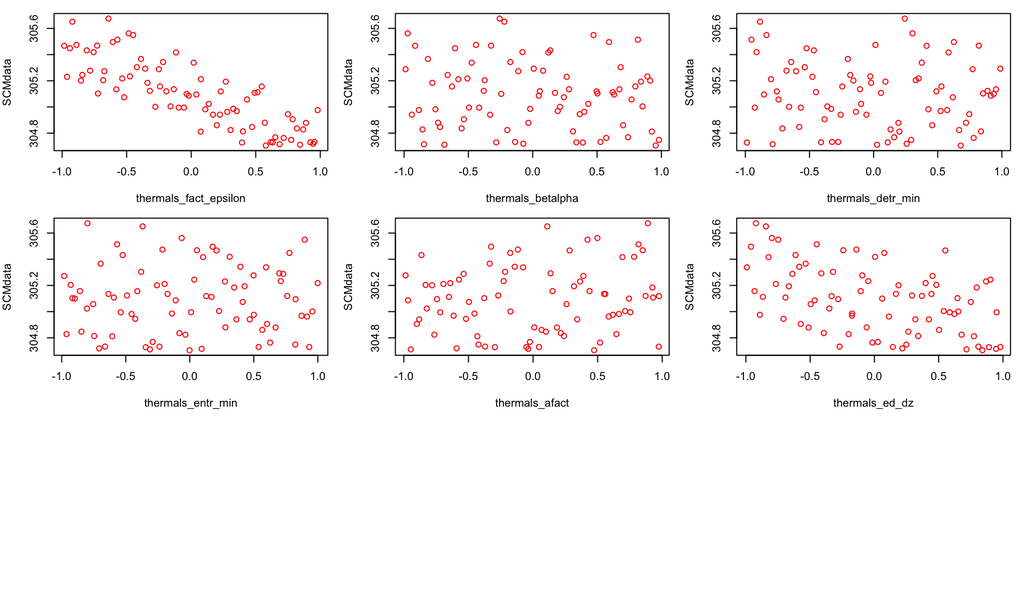

```r
if(nparam*nmetric<2){ par(mfrow = c(1, 1), mar=c(4, 4, 1, 1))
} else if(nparam*nmetric <= 4){ par(mfrow = c(2, 2), mar=c(4, 4, 1, 1))
} else if(nparam*nmetric <= 9){ par(mfrow = c(3, 3), mar=c(4, 4, 1, 1))
} else if(nparam*nmetric <= 16){ par(mfrow = c(4, 4), mar=c(4, 4, 1, 1))
} else if(nparam*nmetric <= 25){ par(mfrow = c(5,5), mar=c(4, 4, 1, 1)) }
for ( iparam in 1:nparam ) {
  for (j in 1:nmetric) {
    plot(tData[,iparam],tData[,nparam+j+1],col=2,xlab=cands[iparam],ylab=metric[j],
         ylim=range(tData[,nparam+j+1]))
  }
}
```

## Build the emulator

We build the emulator for the output variable (metric) `SCMdata`. In this particular example we have just one metric of interest `nmetric=1`, however it is possible to extend `InitialBasisEmulators` to $q>1$ uncorrelated metrics. `InitialBasisEmulators` constructs a GP emulator for one at a time metric of interest in two major steps:

1. Derive the form of a regression function $h(\boldsymbol{x})$ by using a stepwise regression procedure. We use function `EMULATE.lm`.
2. Construct a full GP emulator with a function `EMULATE.gpstan`.

```r
listnew <-lapply(1:nmetric,function(k) names(tData[1:nparam]))
myem.lm <-InitialBasisEmulators(tData=tData,HowManyEmulators=nmetric,additionalVariables = listnew)
```

The output of a function is a list where each member of a list corresponds to an object `StanEmulator` obtained for each metric of interest.

```r
names(myem.lm[[1]])
```

```
##  [1] "Names"              "linModel"           "mainEffects"
##  [4] "Interactions"       "Factors"            "FactorInteractions"
##  [7] "ThreeWayInters"     "Fouriers"           "pre.Lists"
## [10] "DataString"         "ResponseString"     "Design"
## [13] "tF"                 "H"                  "ParameterSamples"
## [16] "FastParts"          "StanModel"          "prior.params"
## [19] "init.list"
```

For example, we could consider a regression function $h(\boldsymbol{x})$ used in the definition of the mean function for a GP emulator

```r
summary(myem.lm[[1]]$linModel)
```

```
##
## Call:
## lm(formula = SCMdata ~ thermals_fact_epsilon + thermals_ed_dz +
##     I(thermals_ed_dz^2) + thermals_afact + thermals_betalpha +
##     I(thermals_afact * thermals_fact_epsilon) + I(thermals_betalpha *
##     thermals_fact_epsilon) + I(thermals_afact * thermals_ed_dz) +
##     I(thermals_betalpha * thermals_ed_dz), data = tData)
##
## Residuals:
##      Min       1Q   Median       3Q      Max
## -0.05377 -0.01784 -0.00068  0.01922  0.06294
##
## Coefficients:
##                                                Estimate Std. Error
## (Intercept)                                  305.073147   0.004928
## thermals_fact_epsilon                         -0.367340   0.005661
## thermals_ed_dz                                -0.229555   0.005681
## I(thermals_ed_dz^2)                            0.064581   0.011089
## thermals_afact                                 0.056713   0.005620
## thermals_betalpha                             -0.039986   0.005723
## I(thermals_afact * thermals_fact_epsilon)     -0.054366   0.010243
## I(thermals_betalpha * thermals_fact_epsilon)   0.031872   0.009885
## I(thermals_afact * thermals_ed_dz)            -0.038076   0.009803
## I(thermals_betalpha * thermals_ed_dz)         -0.055234   0.009766
##                                                t value Pr(>|t|)
## (Intercept)                                  61903.775  < 2e-16 ***
## thermals_fact_epsilon                          -64.889  < 2e-16 ***
## thermals_ed_dz                                 -40.409  < 2e-16 ***
## I(thermals_ed_dz^2)                              5.824 1.60e-07 ***
## thermals_afact                                  10.091 2.74e-15 ***
## thermals_betalpha                               -6.987 1.32e-09 ***
## I(thermals_afact * thermals_fact_epsilon)       -5.307 1.24e-06 ***
## I(thermals_betalpha * thermals_fact_epsilon)     3.224  0.00192 **
## I(thermals_afact * thermals_ed_dz)              -3.884  0.00023 ***
## I(thermals_betalpha * thermals_ed_dz)           -5.656 3.14e-07 ***
## ---
## Signif. codes:  0 '***' 0.001 '**' 0.01 '*' 0.05 '.' 0.1 ' ' 1
##
## Residual standard error: 0.02888 on 70 degrees of freedom
## Multiple R-squared:  0.9887, Adjusted R-squared:  0.9873
## F-statistic: 683.1 on 9 and 70 DF,  p-value: < 2.2e-16
```

## Diagnostics for a GP emulator

Since we are operating with Stan, it is crucial to check the convergence of posterior samples obtained for GP emulator hyperparameters.

```
## 'pars' not specified. Showing first 10 parameters by default.
```

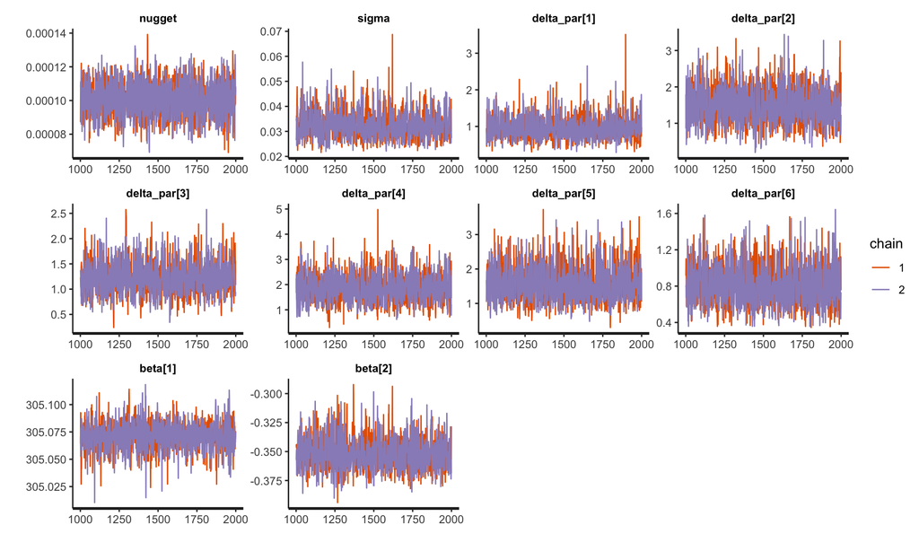

```r
traceplot(myem.lm[[1]]$StanModel)
```

We also validate the performance of GP emulator by considering the Leave One Out (LOO) diagnostics plots. The black dots and error bars shows the predictions $\pm2\times$ standard deviation prediction intervals from the leave one out emulators, whilst the green/red dots are the true model output coloured by whether or not the true lies within the error bar.

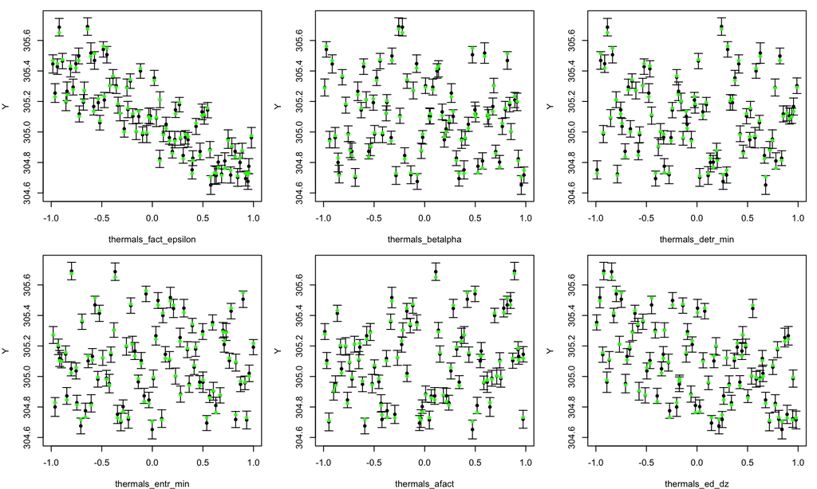

```r
for (i in 1:nmetric) {
  tLOOs1 <- LOO.plot(StanEmulator = myem.lm[[i]] , ParamNames=names(tData)[1:nparam])
}
```